# SHRS Market Analysis — Detailed Industry Employment (2022 Vintage)

BLS Employment Projections Table 2.11 · 2022–2032 Cycle

SHRS MQE Capstone Team

2026-02-14

# 0 — Setup

```r
library(tidyverse)
library(scales)
library(knitr)
library(kableExtra)
```

```r
soc_crosswalk <- tribble(
  ~shrs_program, ~shrs_dept, ~soc_code,  ~occupation_title,
  "SLP",         "CSD",      "29-1127",  "Speech-Language Pathologists",
  "AuD",         "CSD",      "29-1181",  "Audiologists",
  "HIM",         "HIM",      "29-9021",  "Health Information Technologists and Medical Registrars",
  "OTD",         "RST",      "29-1122",  "Occupational Therapists",
  "DPT",         "RST",      "29-1123",  "Physical Therapists",
  "PAS",         "PAS",      "29-1071",  "Physician Assistants",
  "AT",          "SMN",      "29-9091",  "Athletic Trainers",
  "DN",          "SMN",      "29-1031",  "Dietitians and Nutritionists",
  "SS",          "SMN",      "29-1128",  "Exercise Physiologists"
)

DATA_PATH <- "/Users/gpps/Documents/SHRS_Analysis/market_analysis/v3data/projections_csv/industry_csv/2022/2022_industry-2022 - Table 2.11.csv"

VINTAGE <- 2022
CYCLE   <- "2022-2032"

# NAICS mapping — 2022 uses SHORT NAICS codes (e.g., "6213" not "621300")
# Also does NOT break out 621340 — only goes to 4-digit level for therapy offices
shrs_naics <- tribble(
  ~naics_code, ~naics_label,                                              ~shrs_relevance,
  "62",        "Health care and social assistance",                       "Umbrella sector",
  "621",       "Ambulatory health care services",                         "Primary outpatient umbrella",
  "6211",      "Offices of physicians",                                   "PAS, DN setting",
  "6213",      "Offices of other health practitioners",                   "Umbrella for SLP, AuD, OTD, DPT, AT",
  "6214",      "Outpatient care centers",                                 "Multi-program setting",
  "6215",      "Medical and diagnostic laboratories",                     "HIM potential",
  "6216",      "Home health care services",                               "SLP, OTD, DPT, DN home health",
  "6219",      "Other ambulatory health care services",                   "AT, SS primary",
  "622",       "Hospitals",                                               "All SHRS programs",
  "623",       "Nursing and residential care facilities",                 "SLP, OTD, DPT, DN — SNF/LTC",
  "624",       "Social assistance",                                       "SLP (early intervention), DN"
)
```

```r
clean_num <- function(x) {
  x <- str_remove_all(x, ",")
  x <- str_replace_all(x, "\u2014|\u2013|--|-", NA_character_)
  as.numeric(x)
}
```

# 1 — Load & Clean Data

**CRITICAL STRUCTURAL DIFFERENCES** from 2023/2024 vintages:

1. **14 columns** (not 11): includes historical employment (2012), historical change, and historical CAGR in addition to projected data
2. **No explicit percent-change column** — must compute from numeric change and base
3. **Blank separator rows** between sections
4. **NAICS shorthand codes** (e.g., `6213` not `621300`, `622` not `622000`)
5. **Does NOT break out NAICS 621340** — the most granular therapy industry data is at `6213` (all “other health practitioners”), which includes chiropractors, optometrists, mental health, AND PT/OT/SLP/AuD combined
6. Uses `NA` text string for some NAICS codes of non-standard rows

**Column layout (14 columns):**

| Pos | Content |
| --- | --- |
| 1 | Industry name + NAICS code |
| 2 | Employment, 2012 (thousands) |
| 3 | Employment, 2022 (thousands) |
| 4 | Employment, 2032 (thousands) |
| 5 | Employment change, 2012–22 (numeric) |
| 6 | Employment change, 2022–32 (numeric) |
| 7 | CAGR, employment, 2012–22 |
| 8 | CAGR, employment, 2022–32 |
| 9 | Output, 2012 (billions $) |
| 10 | Output, 2022 (billions $) |
| 11 | Output, 2032 (billions $) |
| 12 | CAGR, output, 2012–22 |
| 13 | CAGR, output, 2022–32 |

**Wait** — the header shows 14 columns but column 1 is “Industry, 2022 NAICS” which is a single column containing both the title and the NAICS code, separated by a comma within the cell. Let me parse carefully.

```r
raw <- read_csv(DATA_PATH, col_types = cols(.default = "c"), col_names = FALSE)

# This vintage has a composite first column ("Industry, 2022 NAICS")
# but it's actually TWO logical columns packed into the CSV header
# Let's check the actual column count
n_cols <- ncol(raw)
cat("Actual columns in CSV:", n_cols, "\n")
```

```
## Actual columns in CSV: 14
```

```r
# Column names by position — adapt based on what we see
if (n_cols == 14) {
  colnames(raw) <- c(
    "industry_title", "naics_code",
    "emp_hist", "emp_base", "emp_proj",
    "emp_change_hist", "emp_change_proj",
    "cagr_hist", "cagr_proj",
    "output_hist", "output_base", "output_proj",
    "output_cagr_hist", "output_cagr_proj"
  )
} else {
  # Fallback: treat as 13 columns with embedded NAICS
  colnames(raw) <- paste0("V", 1:n_cols)
  cat("WARNING: Unexpected column count. Manual inspection needed.\n")
}

# Drop header row
raw <- raw[-1, ]

# Clean footnote markers
raw <- raw %>%
  mutate(industry_title = str_remove_all(industry_title, "\\(\\d+\\)|\\[\\d+\\]") %>%
           str_trim())

# Remove blank separator rows
raw <- raw %>%
  filter(!is.na(industry_title) & industry_title != "")

# Clean NAICS codes (sometimes "NA" text, sometimes actual codes)
raw <- raw %>%
  mutate(naics_code = str_trim(naics_code),
         naics_code = if_else(naics_code == "NA", NA_character_, naics_code))

# Convert numeric columns
df <- raw %>%
  mutate(across(-c(industry_title, naics_code), clean_num))

# Compute percent change (not provided in this vintage)
df <- df %>%
  mutate(
    emp_pct_hist = round((emp_change_hist / emp_hist) * 100, 1),
    emp_pct_proj = round((emp_change_proj / emp_base) * 100, 1)
  )

cat("Loaded", nrow(df), "rows for", CYCLE, "cycle (after cleaning)\n")
```

```
## Loaded 250 rows for 2022-2032 cycle (after cleaning)
```

```r
df %>%
  head(15) %>%
  select(industry_title, naics_code, emp_base, emp_proj, emp_pct_proj, cagr_proj) %>%
  kable(digits = 1, format.args = list(big.mark = ","),
        caption = "Table 2.11 Preview (growth % computed)") %>%
  kable_styling(bootstrap_options = c("striped", "hover"), full_width = FALSE)
```

Table 2.11 Preview (growth % computed)

| industry_title | naics_code | emp_base | emp_proj | emp_pct_proj | cagr_proj |
| --- | --- | --- | --- | --- | --- |
| Total, all industries | NA | 164,482.6 | 169,148.1 | 2.8 | 0.3 |
| Nonagriculture wage and salary | NA | 153,185.5 | 157,779.4 | 3.0 | 0.3 |
| Mining | 21 | 559.9 | 545.4 | NA | NA |
| Oil and gas extraction | 211 | 116.7 | 111.0 | NA | NA |
| Mining, except oil and gas | 212 | 183.0 | 168.3 | NA | NA |
| Coal mining | 2121 | 40.4 | 22.9 | NA | NA |
| Metal ore mining | 2122 | 42.9 | 45.4 | 5.8 | 0.6 |
| Nonmetallic mineral mining and quarrying | 2123 | 99.7 | 100.0 | 0.3 | 0.0 |
| Support activities for mining | 213 | 260.2 | 266.1 | 2.3 | 0.2 |
| Utilities | 22 | 553.6 | 539.2 | NA | NA |
| Electric power generation, transmission and distribution | 2211 | 384.3 | 378.2 | NA | NA |
| Natural gas distribution | 2212 | 112.8 | 104.4 | NA | NA |
| Water, sewage and other systems | 2213 | 56.5 | 56.6 | 0.2 | 0.0 |
| Construction | 23 | 7,748.0 | 7,862.9 | 1.5 | 0.1 |
| Manufacturing | 31-33 | 12,825.7 | 12,712.3 | NA | NA |

# 2 — Benchmarks

```r
# Total row — labeled "Total, all industries" in this vintage
total_row <- df %>%
  filter(str_detect(industry_title, regex("^Total.*all industries", ignore_case = TRUE))) %>%
  slice(1)

total_emp  <- total_row$emp_base
total_pct  <- total_row$emp_pct_proj
total_cagr <- total_row$cagr_proj

# Healthcare — labeled "Health care and social assistance" with NAICS "62"
hc_row <- df %>%
  filter(naics_code == "62" |
         str_detect(industry_title, regex("^Health care and social assistance$",
                                          ignore_case = TRUE))) %>%
  slice(1)

hc_emp_base <- hc_row$emp_base
hc_emp_proj <- hc_row$emp_proj
hc_pct      <- hc_row$emp_pct_proj
hc_cagr     <- hc_row$cagr_proj

cat("Benchmarks (", CYCLE, "):\n")
```

```
## Benchmarks ( 2022-2032 ):
```

```r
cat("  Total economy growth:   ", total_pct, "% | CAGR ", total_cagr, "%\n")
```

```
##   Total economy growth:    2.8 % | CAGR  0.3 %
```

```r
cat("  HC & Social Assistance: ", hc_pct, "% | CAGR ", hc_cagr, "%\n")
```

```
##   HC & Social Assistance:  10.2 % | CAGR  1 %
```

```r
cat("  HC/Total ratio:         ", round(hc_pct / total_pct, 2), "x\n")
```

```
##   HC/Total ratio:          3.64 x
```

# 3 — SHRS-Relevant Industries

**Important limitation for this vintage:** The 2022 data uses **4-digit NAICS** as its finest granularity for therapy practices. NAICS 6213 (“Offices of other health practitioners”) includes chiropractors, optometrists, mental health practitioners, PT/OT/SLP/AuD, and all other practitioners combined. This means we cannot isolate NAICS 621340 (therapy offices) as we can in 2023/2024 vintages.

Similarly, 6219 (“Other ambulatory health care services”) is the combined total that includes ambulance services and other ambulatory HC — we cannot isolate 621990.

```r
shrs_ind <- df %>%
  filter(naics_code %in% shrs_naics$naics_code) %>%
  left_join(shrs_naics, by = "naics_code") %>%
  mutate(
    growth_vs_total = round(emp_pct_proj - total_pct, 1),
    growth_vs_hc    = round(emp_pct_proj - hc_pct, 1)
  )

cat("Found", nrow(shrs_ind), "of", nrow(shrs_naics), "target SHRS industries\n")
```

```
## Found 11 of 11 target SHRS industries
```

```r
shrs_ind %>%
  select(
    Industry          = industry_title,
    NAICS             = naics_code,
    `Emp 2012 (K)`    = emp_hist,
    `Emp 2022 (K)`    = emp_base,
    `Emp 2032 (K)`    = emp_proj,
    `Hist Growth (%)`  = emp_pct_hist,
    `Proj Growth (%)`  = emp_pct_proj,
    `CAGR (%)`         = cagr_proj,
    `vs Total (pp)`    = growth_vs_total,
    `vs HC (pp)`       = growth_vs_hc
  ) %>%
  kable(digits = 1, format.args = list(big.mark = ","),
        caption = paste0("SHRS-Relevant Industries (", CYCLE, ") — 4-digit NAICS")) %>%
  kable_styling(bootstrap_options = c("striped", "hover"), full_width = FALSE)
```

SHRS-Relevant Industries (2022-2032) — 4-digit NAICS

| Industry | NAICS | Emp 2012 (K) | Emp 2022 (K) | Emp 2032 (K) | Hist Growth (%) | Proj Growth (%) | CAGR (%) | vs Total (pp) | vs HC (pp) |
| --- | --- | --- | --- | --- | --- | --- | --- | --- | --- |
| Health care and social assistance | 62 | 17,428.0 | 20,555.0 | 22,647.0 | 17.9 | 10.2 | 1.0 | 7.4 | 0.0 |
| Ambulatory health care services | 621 | 6,306.4 | 8,121.9 | 9,182.9 | 28.8 | 13.1 | 1.2 | 10.3 | 2.9 |
| Offices of physicians | 6211 | 2,339.8 | 2,808.8 | 3,009.8 | 20.0 | 7.2 | 0.7 | 4.4 | -3.0 |
| Offices of other health practitioners | 6213 | 726.9 | 1,084.7 | 1,292.6 | 49.2 | 19.2 | 1.8 | 16.4 | 9.0 |
| Outpatient care centers | 6214 | 699.0 | 1,034.1 | 1,253.6 | 47.9 | 21.2 | 1.9 | 18.4 | 11.0 |
| Medical and diagnostic laboratories | 6215 | 235.5 | 321.1 | 348.3 | 36.3 | 8.5 | 0.8 | 5.7 | -1.7 |
| Home health care services | 6216 | 1,185.0 | 1,533.6 | 1,843.8 | 29.4 | 20.2 | 1.9 | 17.4 | 10.0 |
| Other ambulatory health care services | 6219 | 266.5 | 324.7 | 358.8 | 21.8 | 10.5 | 1.0 | 7.7 | 0.3 |
| Hospitals | 622 | 4,779.0 | 5,165.0 | 5,429.0 | 8.1 | 5.1 | 0.5 | 2.3 | -5.1 |
| Nursing and residential care facilities | 623 | 3,196.2 | 3,012.0 | 3,131.6 | NA | 4.0 | 0.4 | 1.2 | -6.2 |
| Social assistance | 624 | 3,146.4 | 4,256.1 | 4,903.5 | 35.3 | 15.2 | 1.4 | 12.4 | 5.0 |

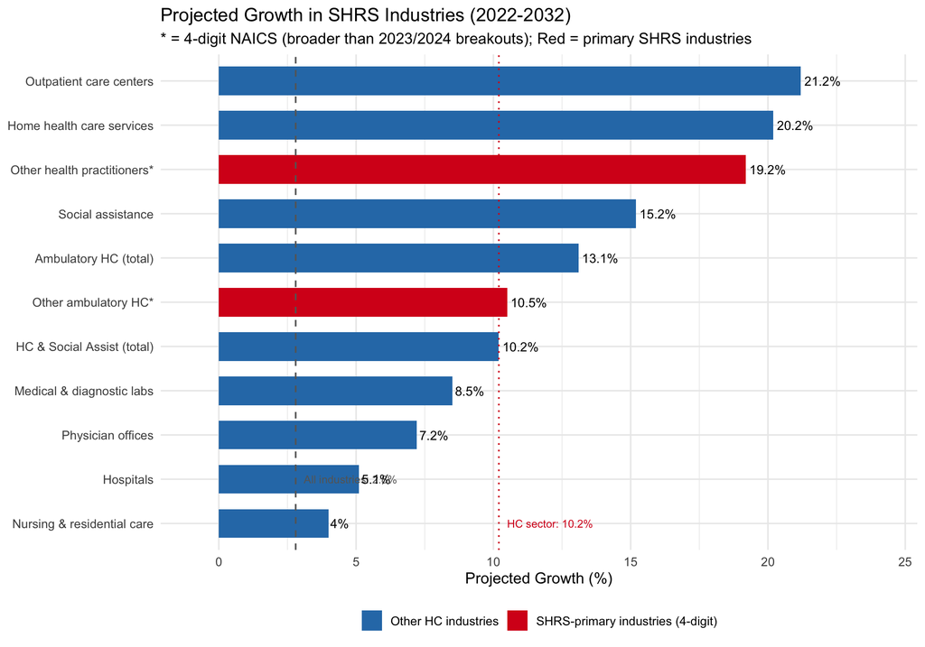

```r
shrs_ind %>%
  filter(!is.na(emp_pct_proj)) %>%
  mutate(
    short_name = case_when(
      naics_code == "62"   ~ "HC & Social Assist (total)",
      naics_code == "621"  ~ "Ambulatory HC (total)",
      naics_code == "6211" ~ "Physician offices",
      naics_code == "6213" ~ "Other health practitioners*",
      naics_code == "6214" ~ "Outpatient care centers",
      naics_code == "6215" ~ "Medical & diagnostic labs",
      naics_code == "6216" ~ "Home health care services",
      naics_code == "6219" ~ "Other ambulatory HC*",
      naics_code == "622"  ~ "Hospitals",
      naics_code == "623"  ~ "Nursing & residential care",
      naics_code == "624"  ~ "Social assistance",
      TRUE ~ str_trunc(industry_title, 35)
    ),
    is_primary = naics_code %in% c("6213", "6219")
  ) %>%
  ggplot(aes(x = reorder(short_name, emp_pct_proj), y = emp_pct_proj,
             fill = is_primary)) +
  geom_col(width = 0.65) +
  geom_hline(yintercept = total_pct, linetype = "dashed",
             color = "gray40", linewidth = 0.6) +
  geom_hline(yintercept = hc_pct, linetype = "dotted",
             color = "#d7191c", linewidth = 0.6) +
  annotate("text", x = 2, y = total_pct + 0.3,
           label = paste0("All industries: ", total_pct, "%"),
           hjust = 0, size = 3, color = "gray40") +
  annotate("text", x = 1, y = hc_pct + 0.3,
           label = paste0("HC sector: ", hc_pct, "%"),
           hjust = 0, size = 3, color = "#d7191c") +
  geom_text(aes(label = paste0(emp_pct_proj, "%")), hjust = -0.1, size = 3.5) +
  coord_flip() +
  scale_fill_manual(values = c("FALSE" = "#2c7bb6", "TRUE" = "#d7191c"),
                    labels = c("Other HC industries",
                               "SHRS-primary industries (4-digit)"),
                    name = NULL) +
  scale_y_continuous(expand = expansion(mult = c(0.1, 0.2))) +
  labs(
    title = paste0("Projected Growth in SHRS Industries (", CYCLE, ")"),
    subtitle = "* = 4-digit NAICS (broader than 2023/2024 breakouts); Red = primary SHRS industries",
    x = NULL, y = "Projected Growth (%)"
  ) +
  theme_minimal(base_size = 12) +
  theme(legend.position = "bottom")
```

# 4 — Primary SHRS Industry Deep-Dive

## 4.1 NAICS 6213: Offices of Other Health Practitioners

**IMPORTANT:** In the 2022 vintage, this is the **broadest available** proxy for NAICS 621340 (therapy offices). It includes chiropractors, optometrists, mental health practitioners, AND PT/OT/SLP/AuD offices.

```r
ind_6213 <- df %>% filter(naics_code == "6213")

if (nrow(ind_6213) > 0) {
  cat("NAICS 6213 — Offices of Other Health Practitioners\n")
  cat("  NOTE: Broader than 621340; includes chiro, optom, mental health + therapy\n")
  cat("  Emp (2012):        ", comma(ind_6213$emp_hist * 1000), "\n")
  cat("  Emp (", VINTAGE, "):    ", comma(ind_6213$emp_base * 1000), "\n")
  cat("  Proj (", VINTAGE+10, "):  ", comma(ind_6213$emp_proj * 1000), "\n")
  cat("  Hist growth:       ", ind_6213$emp_pct_hist, "%\n")
  cat("  Proj growth:       ", ind_6213$emp_pct_proj, "%\n")
  cat("  CAGR:              ", ind_6213$cagr_proj, "%\n")
  cat("  vs Total:          +", round(ind_6213$emp_pct_proj - total_pct, 1), " pp\n")
}
```

```
## NAICS 6213 — Offices of Other Health Practitioners
##   NOTE: Broader than 621340; includes chiro, optom, mental health + therapy
##   Emp (2012):         726,900
##   Emp ( 2022 ):     1,084,700
##   Proj ( 2032 ):   1,292,600
##   Hist growth:        49.2 %
##   Proj growth:        19.2 %
##   CAGR:               1.8 %
##   vs Total:          + 16.4  pp
```

## 4.2 NAICS 6219: Other Ambulatory Health Care Services

Broader proxy for NAICS 621990.

```r
ind_6219 <- df %>% filter(naics_code == "6219")

if (nrow(ind_6219) > 0) {
  cat("NAICS 6219 — Other Ambulatory Health Care Services\n")
  cat("  NOTE: Broader than 621990; includes ambulance services\n")
  cat("  Emp (", VINTAGE, "):    ", comma(ind_6219$emp_base * 1000), "\n")
  cat("  Proj (", VINTAGE+10, "):  ", comma(ind_6219$emp_proj * 1000), "\n")
  cat("  Proj growth:       ", ind_6219$emp_pct_proj, "%\n")
  cat("  CAGR:              ", ind_6219$cagr_proj, "%\n")
}
```

```
## NAICS 6219 — Other Ambulatory Health Care Services
##   NOTE: Broader than 621990; includes ambulance services
##   Emp ( 2022 ):     324,700
##   Proj ( 2032 ):   358,800
##   Proj growth:        10.5 %
##   CAGR:               1 %
```

## 4.3 Historical vs Projected Growth

This vintage uniquely provides **both** historical (2012–2022) and projected (2022–2032) growth, enabling a momentum analysis.

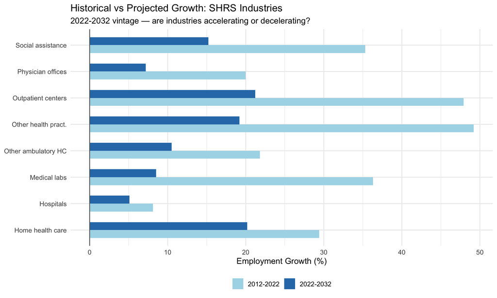

```r
momentum <- shrs_ind %>%
  filter(!is.na(emp_pct_hist), !is.na(emp_pct_proj),
         !naics_code %in% c("62", "621")) %>%
  mutate(
    short_name = case_when(
      naics_code == "6211" ~ "Physician offices",
      naics_code == "6213" ~ "Other health pract.",
      naics_code == "6214" ~ "Outpatient centers",
      naics_code == "6215" ~ "Medical labs",
      naics_code == "6216" ~ "Home health care",
      naics_code == "6219" ~ "Other ambulatory HC",
      naics_code == "622"  ~ "Hospitals",
      naics_code == "623"  ~ "Nursing & residential",
      naics_code == "624"  ~ "Social assistance",
      TRUE ~ str_trunc(industry_title, 25)
    ),
    momentum = emp_pct_proj - emp_pct_hist,
    direction = if_else(momentum >= 0, "Accelerating", "Decelerating")
  )

momentum %>%
  select(short_name, emp_pct_hist, emp_pct_proj) %>%
  pivot_longer(-short_name, names_to = "period", values_to = "growth") %>%
  mutate(period = if_else(period == "emp_pct_hist", "2012-2022", "2022-2032")) %>%
  ggplot(aes(x = short_name, y = growth, fill = period)) +
  geom_col(position = "dodge", width = 0.6) +
  geom_hline(yintercept = 0, color = "gray40") +
  coord_flip() +
  scale_fill_manual(values = c("2012-2022" = "#abd9e9", "2022-2032" = "#2c7bb6")) +
  labs(
    title = "Historical vs Projected Growth: SHRS Industries",
    subtitle = paste0(CYCLE, " vintage — are industries accelerating or decelerating?"),
    x = NULL, y = "Employment Growth (%)", fill = NULL
  ) +
  theme_minimal(base_size = 12) +
  theme(legend.position = "bottom")
```

```r
momentum %>%
  select(
    Industry          = short_name,
    `Hist Growth (%)`  = emp_pct_hist,
    `Proj Growth (%)`  = emp_pct_proj,
    Momentum           = momentum,
    Direction          = direction
  ) %>%
  arrange(desc(Momentum)) %>%
  kable(digits = 1,
        caption = "Growth Momentum: Historical → Projected") %>%
  kable_styling(bootstrap_options = c("striped", "hover"), full_width = FALSE)
```

Growth Momentum: Historical → Projected

| Industry | Hist Growth (%) | Proj Growth (%) | Momentum | Direction |
| --- | --- | --- | --- | --- |
| Hospitals | 8.1 | 5.1 | -3.0 | Decelerating |
| Home health care | 29.4 | 20.2 | -9.2 | Decelerating |
| Other ambulatory HC | 21.8 | 10.5 | -11.3 | Decelerating |
| Physician offices | 20.0 | 7.2 | -12.8 | Decelerating |
| Social assistance | 35.3 | 15.2 | -20.1 | Decelerating |
| Outpatient centers | 47.9 | 21.2 | -26.7 | Decelerating |
| Medical labs | 36.3 | 8.5 | -27.8 | Decelerating |
| Other health pract. | 49.2 | 19.2 | -30.0 | Decelerating |

## 4.4 Output (Revenue) Trends

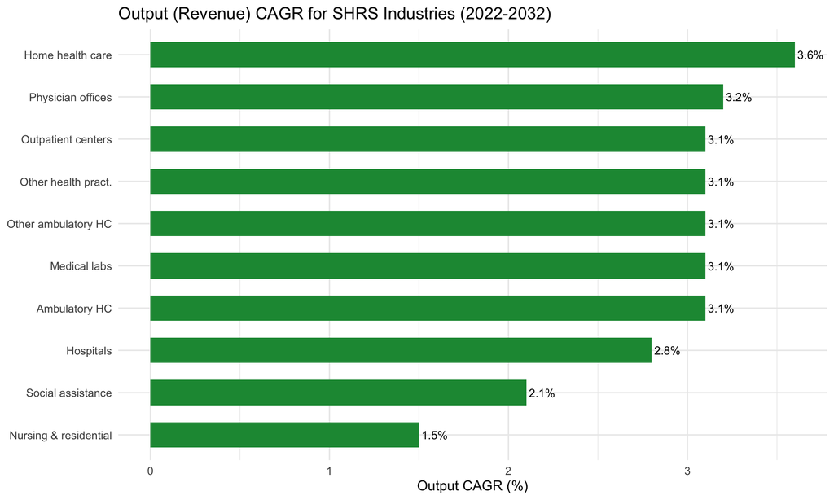

```r
output_ind <- shrs_ind %>%
  filter(!is.na(output_base), !is.na(output_proj),
         !naics_code %in% c("62")) %>%
  mutate(
    output_change = output_proj - output_base,
    output_pct    = round((output_change / output_base) * 100, 1),
    short_name = case_when(
      naics_code == "621"  ~ "Ambulatory HC",
      naics_code == "6211" ~ "Physician offices",
      naics_code == "6213" ~ "Other health pract.",
      naics_code == "6214" ~ "Outpatient centers",
      naics_code == "6215" ~ "Medical labs",
      naics_code == "6216" ~ "Home health care",
      naics_code == "6219" ~ "Other ambulatory HC",
      naics_code == "622"  ~ "Hospitals",
      naics_code == "623"  ~ "Nursing & residential",
      naics_code == "624"  ~ "Social assistance",
      TRUE ~ str_trunc(industry_title, 25)
    )
  )

if (nrow(output_ind) > 0) {
  output_ind %>%
    ggplot(aes(x = reorder(short_name, output_cagr_proj), y = output_cagr_proj)) +
    geom_col(width = 0.6, fill = "#1a9641") +
    geom_text(aes(label = paste0(output_cagr_proj, "%")), hjust = -0.1, size = 3.5) +
    coord_flip() +
    labs(
      title = paste0("Output (Revenue) CAGR for SHRS Industries (", CYCLE, ")"),
      x = NULL, y = "Output CAGR (%)"
    ) +
    theme_minimal(base_size = 12)
}
```

# 5 — HC Sub-Sector Composition

Note: The 2022 vintage uniquely **combines** hospitals and nursing care (“622, 623”) in some summary rows, but also provides them separately.

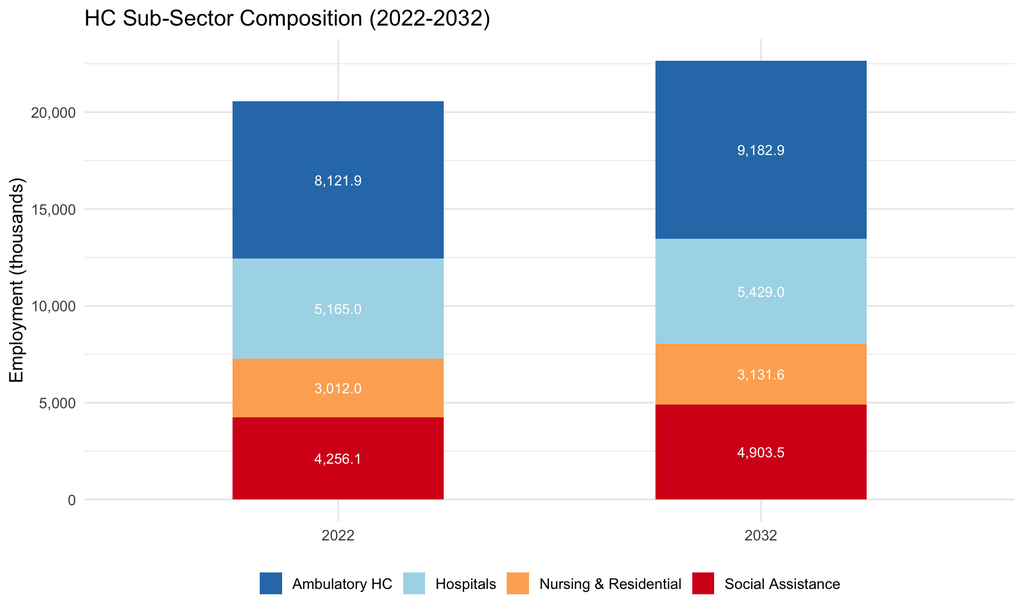

```r
hc_sub <- df %>%
  filter(naics_code %in% c("621", "622", "623", "624")) %>%
  mutate(subsector = case_when(
    naics_code == "621" ~ "Ambulatory HC",
    naics_code == "622" ~ "Hospitals",
    naics_code == "623" ~ "Nursing & Residential",
    naics_code == "624" ~ "Social Assistance"
  ))

hc_sub %>%
  select(subsector, emp_base, emp_proj) %>%
  pivot_longer(-subsector, names_to = "period", values_to = "emp") %>%
  mutate(period = if_else(period == "emp_base",
                          as.character(VINTAGE), as.character(VINTAGE + 10))) %>%
  ggplot(aes(x = period, y = emp, fill = subsector)) +
  geom_col(width = 0.5) +
  geom_text(aes(label = comma(emp, accuracy = 0.1)),
            position = position_stack(vjust = 0.5), size = 3.5, color = "white") +
  scale_fill_manual(values = c("Ambulatory HC" = "#2c7bb6",
                                "Hospitals" = "#abd9e9",
                                "Nursing & Residential" = "#fdae61",
                                "Social Assistance" = "#d7191c")) +
  scale_y_continuous(labels = comma) +
  labs(
    title = paste0("HC Sub-Sector Composition (", CYCLE, ")"),
    x = NULL, y = "Employment (thousands)", fill = NULL
  ) +
  theme_minimal(base_size = 13) +
  theme(legend.position = "bottom")
```

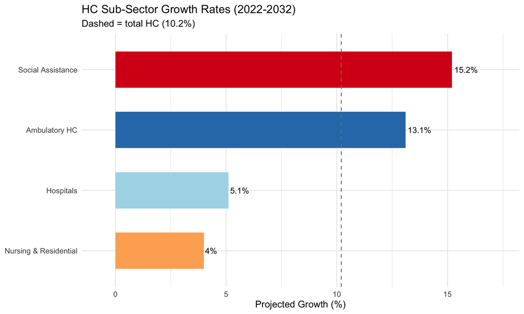

```r
hc_sub %>%
  ggplot(aes(x = reorder(subsector, emp_pct_proj), y = emp_pct_proj,
             fill = subsector)) +
  geom_col(width = 0.6) +
  geom_text(aes(label = paste0(emp_pct_proj, "%")), hjust = -0.1, size = 4) +
  geom_hline(yintercept = hc_pct, linetype = "dashed", color = "gray50") +
  coord_flip() +
  scale_fill_manual(values = c("Ambulatory HC" = "#2c7bb6",
                                "Hospitals" = "#abd9e9",
                                "Nursing & Residential" = "#fdae61",
                                "Social Assistance" = "#d7191c")) +
  scale_y_continuous(expand = expansion(mult = c(0.1, 0.2))) +
  labs(
    title = paste0("HC Sub-Sector Growth Rates (", CYCLE, ")"),
    subtitle = paste0("Dashed = total HC (", hc_pct, "%)"),
    x = NULL, y = "Projected Growth (%)"
  ) +
  theme_minimal(base_size = 13) +
  theme(legend.position = "none")
```

# 6 — Program-to-Industry Scorecard (0–100)

**Note:** Because this vintage only provides 4-digit NAICS, programs that map to 621340 are mapped to 6213 (broader), and programs mapping to 621990 are mapped to 6219 (broader). Scores will be slightly different from 2023/2024 due to this aggregation.

```r
program_map <- tribble(
  ~shrs_program, ~primary_naics, ~primary_label,
  "SLP",         "6213",         "Other health practitioners (incl. therapy)*",
  "AuD",         "6213",         "Other health practitioners (incl. therapy)*",
  "HIM",         "622",          "Hospitals",
  "OTD",         "6213",         "Other health practitioners (incl. therapy)*",
  "DPT",         "6213",         "Other health practitioners (incl. therapy)*",
  "PAS",         "6211",         "Physician offices",
  "AT",          "6219",         "Other ambulatory HC (incl. ambulance)*",
  "DN",          "6211",         "Physician offices",
  "SS",          "6219",         "Other ambulatory HC (incl. ambulance)*"
)

program_ind <- program_map %>%
  left_join(
    df %>% select(naics_code, emp_base, emp_proj, emp_change_proj,
                  emp_pct_proj, cagr_proj),
    by = c("primary_naics" = "naics_code")
  ) %>%
  mutate(
    growth_score = case_when(
      emp_pct_proj >= hc_pct * 2    ~ 100,
      emp_pct_proj >= hc_pct * 1.5  ~ 90,
      emp_pct_proj >= hc_pct        ~ 80,
      emp_pct_proj >= total_pct * 2 ~ 70,
      emp_pct_proj >= total_pct     ~ 60,
      emp_pct_proj >= 0             ~ 40,
      TRUE                          ~ 20
    ),
    size_score = case_when(
      emp_base >= 3000 ~ 100,
      emp_base >= 1000 ~ 85,
      emp_base >= 500  ~ 70,
      emp_base >= 200  ~ 55,
      emp_base >= 100  ~ 40,
      TRUE             ~ 25
    ),
    cagr_score = case_when(
      cagr_proj >= 2.0 ~ 100,
      cagr_proj >= 1.5 ~ 85,
      cagr_proj >= 1.0 ~ 70,
      cagr_proj >= 0.5 ~ 55,
      cagr_proj >= 0.0 ~ 40,
      TRUE             ~ 20
    ),
    composite_score = round((growth_score + size_score + cagr_score) / 3, 0),
    signal = case_when(
      composite_score >= 70 ~ "Green",
      composite_score >= 50 ~ "Yellow",
      TRUE                  ~ "Red"
    )
  )
```

```r
program_ind %>%
  arrange(desc(composite_score)) %>%
  select(
    Program        = shrs_program,
    Industry       = primary_label,
    `Emp (K)`      = emp_base,
    `Growth (%)`   = emp_pct_proj,
    `CAGR (%)`     = cagr_proj,
    `Gr Score`     = growth_score,
    `Sz Score`     = size_score,
    `CAGR Score`   = cagr_score,
    Composite      = composite_score,
    Signal         = signal
  ) %>%
  kable(digits = 1, format.args = list(big.mark = ","),
        caption = paste0("Program Industry Scorecard (", CYCLE,
                          ") — * = broader 4-digit NAICS proxy")) %>%
  kable_styling(bootstrap_options = c("striped", "hover"), full_width = FALSE) %>%
  column_spec(10, bold = TRUE)
```

Program Industry Scorecard (2022-2032) — * = broader 4-digit NAICS proxy

| Program | Industry | Emp (K) | Growth (%) | CAGR (%) | Gr Score | Sz Score | CAGR Score | Composite | Signal |
| --- | --- | --- | --- | --- | --- | --- | --- | --- | --- |
| SLP | Other health practitioners (incl. therapy)* | 1,084.7 | 19.2 | 1.8 | 90 | 85 | 85 | 87 | Green |
| AuD | Other health practitioners (incl. therapy)* | 1,084.7 | 19.2 | 1.8 | 90 | 85 | 85 | 87 | Green |
| OTD | Other health practitioners (incl. therapy)* | 1,084.7 | 19.2 | 1.8 | 90 | 85 | 85 | 87 | Green |
| DPT | Other health practitioners (incl. therapy)* | 1,084.7 | 19.2 | 1.8 | 90 | 85 | 85 | 87 | Green |
| HIM | Hospitals | 5,165.0 | 5.1 | 0.5 | 60 | 100 | 55 | 72 | Green |
| PAS | Physician offices | 2,808.8 | 7.2 | 0.7 | 70 | 85 | 55 | 70 | Green |
| DN | Physician offices | 2,808.8 | 7.2 | 0.7 | 70 | 85 | 55 | 70 | Green |
| AT | Other ambulatory HC (incl. ambulance)* | 324.7 | 10.5 | 1.0 | 80 | 55 | 70 | 68 | Yellow |
| SS | Other ambulatory HC (incl. ambulance)* | 324.7 | 10.5 | 1.0 | 80 | 55 | 70 | 68 | Yellow |

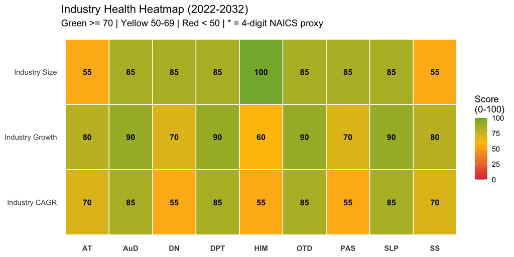

```r
program_ind %>%
  select(shrs_program, growth_score, size_score, cagr_score) %>%
  pivot_longer(-shrs_program, names_to = "dimension", values_to = "score") %>%
  mutate(dimension = case_when(
    dimension == "growth_score" ~ "Industry Growth",
    dimension == "size_score"   ~ "Industry Size",
    dimension == "cagr_score"   ~ "Industry CAGR"
  )) %>%
  ggplot(aes(x = shrs_program, y = dimension, fill = score)) +
  geom_tile(color = "white", linewidth = 0.5) +
  geom_text(aes(label = score), size = 4, fontface = "bold") +
  scale_fill_gradient2(low = "#dc3545", mid = "#ffc107", high = "#28a745",
                        midpoint = 60, limits = c(0, 100),
                        name = "Score\n(0-100)") +
  labs(
    title = paste0("Industry Health Heatmap (", CYCLE, ")"),
    subtitle = "Green >= 70 | Yellow 50-69 | Red < 50 | * = 4-digit NAICS proxy",
    x = NULL, y = NULL
  ) +
  theme_minimal(base_size = 13) +
  theme(axis.text.x = element_text(face = "bold"), panel.grid = element_blank())
```

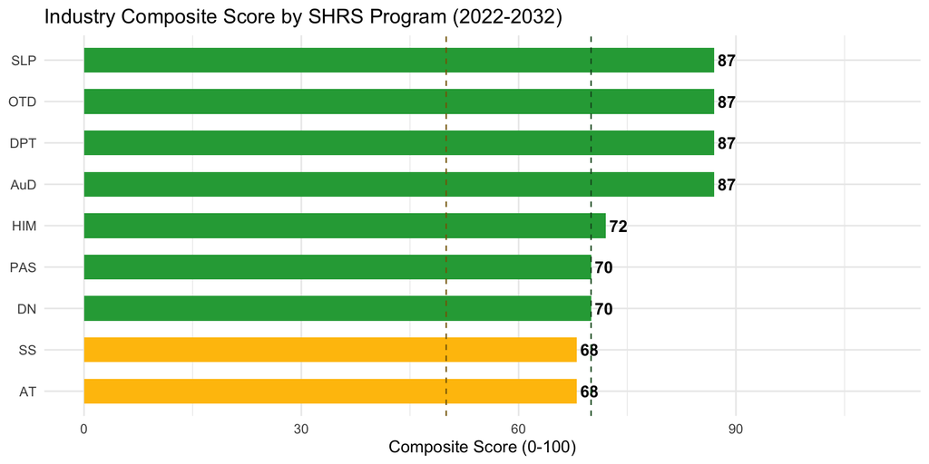

```r
program_ind %>%
  ggplot(aes(x = reorder(shrs_program, composite_score), y = composite_score,
             fill = signal)) +
  geom_col(width = 0.6) +
  geom_text(aes(label = composite_score), hjust = -0.2, size = 4.5, fontface = "bold") +
  geom_hline(yintercept = 70, linetype = "dashed", color = "#155724", linewidth = 0.5) +
  geom_hline(yintercept = 50, linetype = "dashed", color = "#856404", linewidth = 0.5) +
  coord_flip() +
  scale_fill_manual(values = c("Green" = "#28a745", "Yellow" = "#ffc107",
                                "Red" = "#dc3545")) +
  scale_y_continuous(limits = c(0, 110)) +
  labs(
    title = paste0("Industry Composite Score by SHRS Program (", CYCLE, ")"),
    x = NULL, y = "Composite Score (0-100)"
  ) +
  theme_minimal(base_size = 13) +
  theme(legend.position = "none")
```

# 7 — Vintage Comparison Notes

Key differences from 2023/2024 vintages that affect cross-vintage analysis:

```r
cat("1. **NAICS granularity**: 2022 uses 4-digit NAICS (6213, 6219) while 2023/2024\n")
```

1. **NAICS granularity**: 2022 uses 4-digit NAICS (6213, 6219) while 2023/2024

```r
cat("   break out 6-digit (621340, 621390, 621990). Therapy offices are mixed with\n")
```

break out 6-digit (621340, 621390, 621990). Therapy offices are mixed with

```r
cat("   chiropractors, optometrists, and mental health in the 2022 data.\n\n")
```

chiropractors, optometrists, and mental health in the 2022 data.

```r
cat("2. **Growth % computed**: 2022 lacks explicit percent-change columns. Values\n")
```

2. **Growth % computed**: 2022 lacks explicit percent-change columns. Values

```r
cat("   are computed as `change / base * 100` and may differ slightly from BLS\n")
```

are computed as `change / base * 100` and may differ slightly from BLS

```r
cat("   reported values due to rounding.\n\n")
```

reported values due to rounding.

```r
cat("3. **Historical data available**: 2022 uniquely provides 2012–2022 historical\n")
```

3. **Historical data available**: 2022 uniquely provides 2012–2022 historical

```r
cat("   growth alongside projections, enabling momentum analysis.\n\n")
```

growth alongside projections, enabling momentum analysis.

```r
cat("4. **Hospitals + Nursing combined**: Some summary rows in the raw data combine\n")
```

4. **Hospitals + Nursing combined**: Some summary rows in the raw data combine

```r
cat("   NAICS 622 and 623 into a single row, but individual rows also exist.\n\n")
```

NAICS 622 and 623 into a single row, but individual rows also exist.

```r
cat("5. **Nursing care decline**: NAICS 623 shows negative historical growth\n")
```

5. **Nursing care decline**: NAICS 623 shows negative historical growth

```r
cat("   (-0.6% CAGR), partially recovering in projections — reflects SNF industry\n")
```

(-0.6% CAGR), partially recovering in projections — reflects SNF industry

```r
cat("   restructuring and post-COVID challenges.\n")
```

restructuring and post-COVID challenges.

# 8 — Stored Outputs

```r
ind_t211_2022_vintage        <- VINTAGE
ind_t211_2022_cycle          <- CYCLE
ind_t211_2022_total_pct      <- total_pct
ind_t211_2022_total_cagr     <- total_cagr
ind_t211_2022_hc_pct         <- hc_pct
ind_t211_2022_hc_cagr        <- hc_cagr
ind_t211_2022_hc_emp         <- hc_emp_base
ind_t211_2022_shrs_ind       <- shrs_ind
ind_t211_2022_ind_6213       <- ind_6213    # 4-digit proxy for 621340
ind_t211_2022_ind_6219       <- ind_6219    # 4-digit proxy for 621990
ind_t211_2022_program_scores <- program_ind
ind_t211_2022_hc_subsectors  <- hc_sub
ind_t211_2022_momentum       <- momentum
ind_t211_2022_full_df        <- df
ind_t211_2022_naics_note     <- "2022 uses 4-digit NAICS; 621340/621990 not available — use 6213/6219 as proxies"
```

```r
output_registry <- tribble(
  ~variable,                           ~description,
  "ind_t211_2022_vintage",             "Vintage year (2022)",
  "ind_t211_2022_cycle",               "Projection cycle (2022-2032)",
  "ind_t211_2022_total_pct",           "Total economy projected growth % (computed)",
  "ind_t211_2022_total_cagr",          "Total economy CAGR %",
  "ind_t211_2022_hc_pct",              "Healthcare sector projected growth % (computed)",
  "ind_t211_2022_hc_cagr",             "Healthcare sector CAGR %",
  "ind_t211_2022_hc_emp",              "Healthcare employment, base year (thousands)",
  "ind_t211_2022_shrs_ind",            "SHRS-relevant industries dataframe (4-digit NAICS)",
  "ind_t211_2022_ind_6213",            "NAICS 6213 row (Other health practitioners — proxy for 621340)",
  "ind_t211_2022_ind_6219",            "NAICS 6219 row (Other ambulatory HC — proxy for 621990)",
  "ind_t211_2022_program_scores",      "Program-to-industry scorecard (9 programs, 0-100)",
  "ind_t211_2022_hc_subsectors",       "HC sub-sector composition",
  "ind_t211_2022_momentum",            "Historical vs projected growth momentum analysis",
  "ind_t211_2022_full_df",             "Complete Table 2.11 dataframe",
  "ind_t211_2022_naics_note",          "Note: 4-digit NAICS only — 621340/621990 unavailable"
)

output_registry %>%
  kable(caption = "Output Variable Registry — industry_t211_2022.Rmd") %>%
  kable_styling(bootstrap_options = c("striped", "hover"), full_width = FALSE)
```

Output Variable Registry — industry_t211_2022.Rmd

| variable | description |
| --- | --- |
| ind_t211_2022_vintage | Vintage year (2022) |
| ind_t211_2022_cycle | Projection cycle (2022-2032) |
| ind_t211_2022_total_pct | Total economy projected growth % (computed) |
| ind_t211_2022_total_cagr | Total economy CAGR % |
| ind_t211_2022_hc_pct | Healthcare sector projected growth % (computed) |
| ind_t211_2022_hc_cagr | Healthcare sector CAGR % |
| ind_t211_2022_hc_emp | Healthcare employment, base year (thousands) |
| ind_t211_2022_shrs_ind | SHRS-relevant industries dataframe (4-digit NAICS) |
| ind_t211_2022_ind_6213 | NAICS 6213 row (Other health practitioners — proxy for 621340) |
| ind_t211_2022_ind_6219 | NAICS 6219 row (Other ambulatory HC — proxy for 621990) |
| ind_t211_2022_program_scores | Program-to-industry scorecard (9 programs, 0-100) |
| ind_t211_2022_hc_subsectors | HC sub-sector composition |
| ind_t211_2022_momentum | Historical vs projected growth momentum analysis |
| ind_t211_2022_full_df | Complete Table 2.11 dataframe |
| ind_t211_2022_naics_note | Note: 4-digit NAICS only — 621340/621990 unavailable |